# Sindh - displacement analysis

An analysis of PDMA and CCCM partner data

Author

CCCM Working Group

Published

12 October 2022

# Introduction

This analysis explores current displacement figures and trends of the 2022 Pakistan floods, as well as a basic service mapping of currently known displacement sites.

**Limitations:** This analysis is a work-in-progress, currently focusing on the hardest hit Province of Sindh. Once time and data availability permits, the analysis will expand to Balochistan, KPK and Punjab. Currently, the service mapping section shows a small proportion of the total number of sites, due to the availablity. We plan to expand this, once data from additional districts become. For this phase, only formal “Tent City”/“Relief Camps” are shown, although this may be expanded to include informal sites at a later stage.

# Provincial-level displacement and trends

As per the latest Sindh PDMA Sitrep of 10-Oct-2022, 265,374 displaced people are currently in Relief Camps, while 7,392,933 are displaced outside of them

| Sitrep Date | Outside of Relief Camps | In Relief Camps |
| --- | --- | --- |
| 24-Sep | 7,241,370 | 382,871 |
| 25-Sep | 7,229,870 | 380,581 |
| 26-Sep | 7,229,870 | 377,817 |
| 27-Sep | 7,191,510 | 375,454 |
| 28-Sep | 7,296,774 | 371,058 |
| 29-Sep | 7,331,507 | 366,682 |
| 01-Oct | 7,325,575 | 357,855 |
| 02-Oct | 7,325,575 | 354,552 |
| 03-Oct | 7,321,712 | 354,249 |
| 05-Oct | 7,383,023 | 352,484 |
| 06-Oct | 7,383,023 | 359,791 |
| 07-Oct | 7,383,023 | 346,328 |
| 08-Oct | 7,383,023 | 344,797 |
| 09-Oct | 6,311,690 | 273,332 |
| 10-Oct | 7,392,933 | 265,374 |

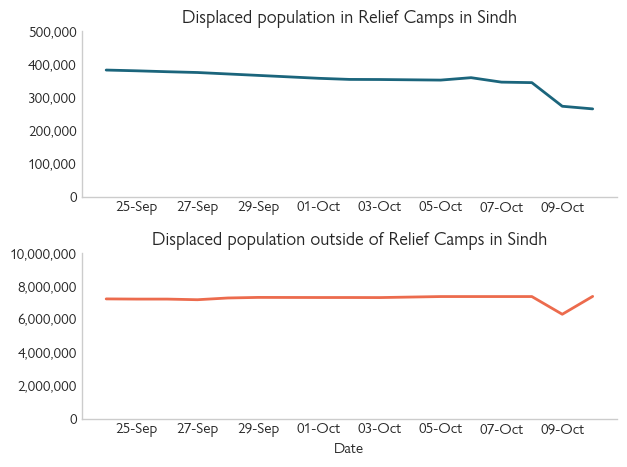

# District-level displacement and trends

*…..work in progress*

# Displacement Sites

[interactive chart not shown]

*For the full size map click* here

Todo: - Show trendlines for all districts, for both in camp and out of camp displaced. - See if theres data on the number of sites, to see trends there - annotate charts - Add current and max flood extents to the webmap to let the viewer explore proximity of sites to flood area